# Assignment 6: Visualization - Aesthetic Mapping

- Line Plot

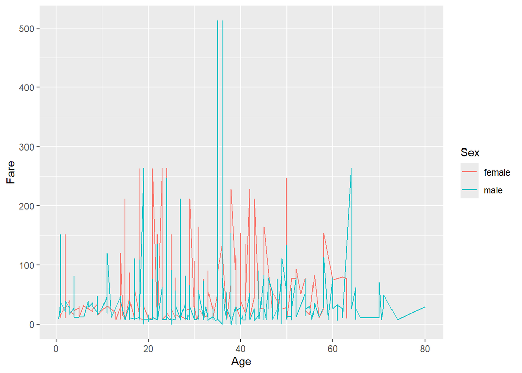

```r
titanic %>% ggplot()+
  geom_line(mapping = aes(x = Age, y = Fare, color = Sex))
```

The line plot shows a lot of variation in fares across different ages for both males and females. There is no clear pattern of fare increasing or decreasing with age.

- Smooth Plot

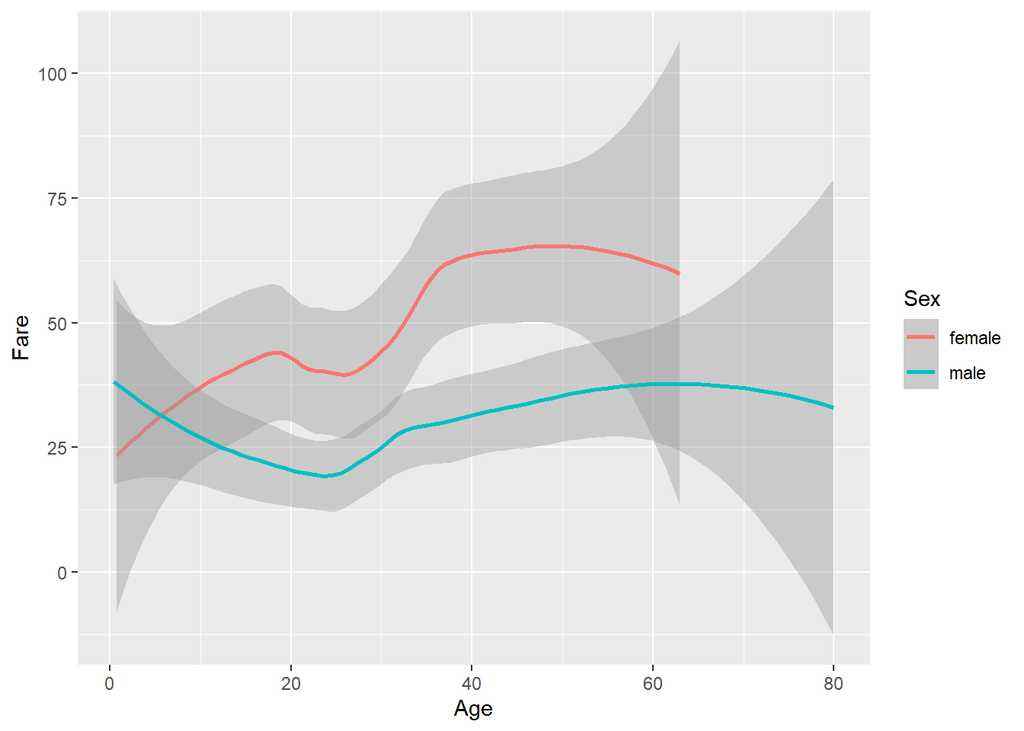

```r
titanic %>% ggplot()+
  geom_smooth(mapping = aes(x = Age, y = Fare, color = Sex))
```

4. For one continuous + one categorical variables: Age and Sex
- Density

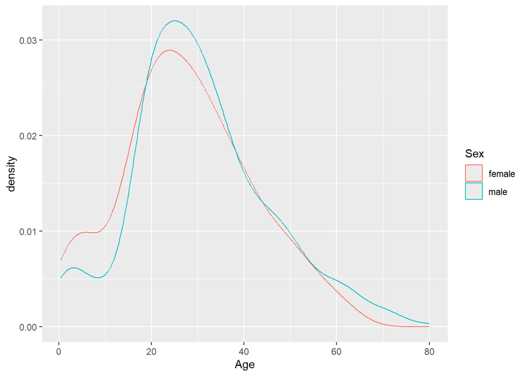

```r
titanic %>% ggplot()+
  geom_density(mapping = aes(x = Age, color = Sex))
```

The density plot shows that the age distributions for male and female passengers were fairly similar. Both groups had the highest concentration of passengers in their 20s.

- BoxPlot

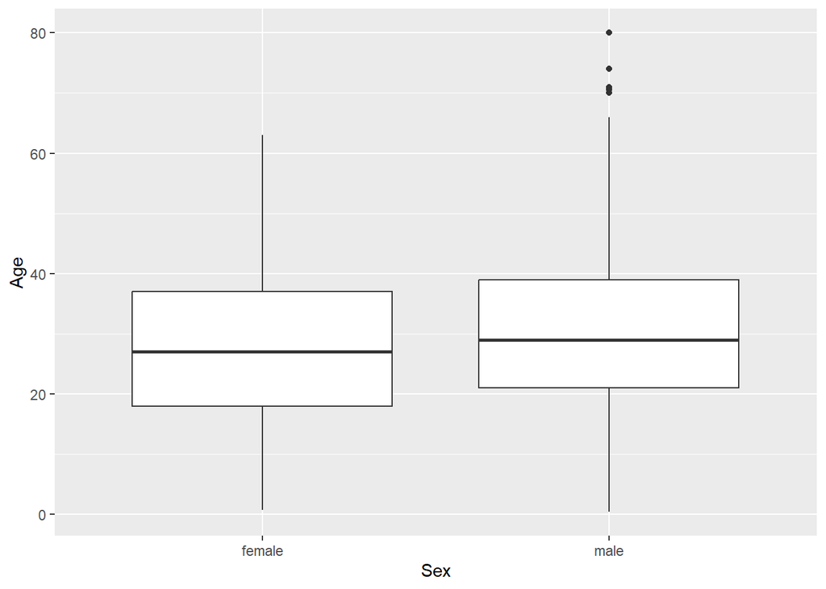

```r
titanic %>% ggplot()+
  geom_boxplot(mapping = aes(x = Sex, y = Age))
```

The boxplot shows that male and female passengers had similar age distributions. The median age for males was slightly higher than for females.

5. For two categorical variables: barplot: Sex and Pclass

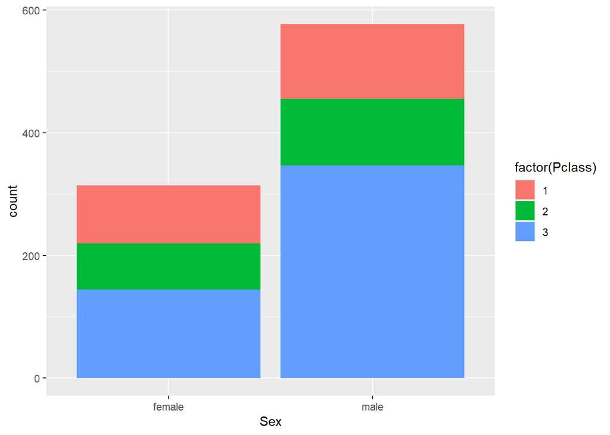

```r
titanic %>% ggplot()+
  geom_bar(mapping = aes(x = Sex, fill = factor(Pclass)))
```

The barplot shows the number of male and female passengers in each passenger class. Males made up a larger number of passengers across the different classes.

6. A plot that contains three variables: Age, Fare and Pclass

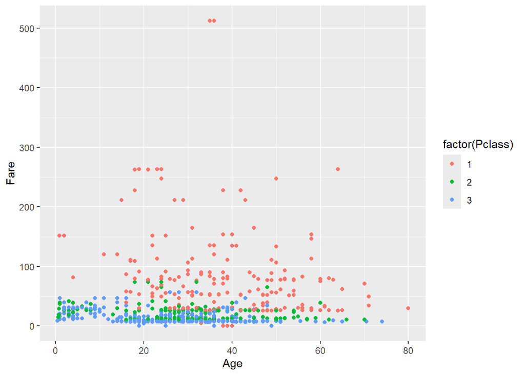

```r
titanic %>% ggplot()+
  geom_point(mapping = aes(x = Age, y = Fare, color = factor(Pclass)))
```

The plot shows the relationship between age and fare across the three passenger classes. First-class passengers generally paid higher fares, while second- and third-class passengers tended to pay lower fares.